# Case_Study_1_Data_Understanding_&_Insights

```r
## Loading required modules

library(stringr)
library(dplyr)
```

```r
library(ggplot2)
```

```r
## Loading survey responses data and subsetting for analysts

df <- read.csv('kaggle_survey_2020_responses.csv')
dim(df)
```

```
## [1] 20037   355
```

## Data Understanding

```r
## Listing columns

colnames(df)[1:10]
```

```
##  [1] "Time.from.Start.to.Finish..seconds." "Q1"
##  [3] "Q2"                                  "Q3"
##  [5] "Q4"                                  "Q5"
##  [7] "Q6"                                  "Q7_Part_1"
##  [9] "Q7_Part_2"                           "Q7_Part_3"
```

```r
## Listing Questions

df[1,][1:5]
```

```
##   Time.from.Start.to.Finish..seconds.                          Q1
## 1               Duration (in seconds) What is your age (# years)?
##                                       Q2
## 1 What is your gender? - Selected Choice
##                                          Q3
## 1 In which country do you currently reside?
##                                                                                                                Q4
## 1 What is the highest level of formal education that you have attained or plan to attain within the next 2 years?
```

```r
## Preparing a data frame containing question numbers and questions

q_header <- colnames(df)[2:length(colnames(df))]
question <- unlist(df[1,2:ncol(df)])
q_df <- data.frame(q_header, question)
print(str(q_df))
```

```
## 'data.frame':    354 obs. of  2 variables:
##  $ q_header: chr  "Q1" "Q2" "Q3" "Q4" ...
##  $ question: chr  "What is your age (# years)?" "What is your gender? - Selected Choice" "In which country do you currently reside?" "What is the highest level of formal education that you have attained or plan to attain within the next 2 years?" ...
## NULL
```

```r
# Extracting questions numbers from question headers
ques_num <- str_split(q_df$q_header,"_")
ques_num <- unlist(lapply(ques_num, function(x){return(x[1])}))
q_df$ques_num <- ques_num
print(str(q_df))
```

```
## 'data.frame':    354 obs. of  3 variables:
##  $ q_header: chr  "Q1" "Q2" "Q3" "Q4" ...
##  $ question: chr  "What is your age (# years)?" "What is your gender? - Selected Choice" "In which country do you currently reside?" "What is the highest level of formal education that you have attained or plan to attain within the next 2 years?" ...
##  $ ques_num: chr  "Q1" "Q2" "Q3" "Q4" ...
## NULL
```

```r
## Extracting question keys from question headers

get_ques_key <- function(x){
  if(length(x)>1 && (x[2] == 'A' | x[2] == 'B')){
    a <- paste(x[1],x[2],sep = "_")
    return(a)
  }
  else{return(x[1])}
}

ques_key <- str_split(q_df$q_header,"_")
q_df$ques_keys <- unlist(lapply(ques_key, get_ques_key))
str(q_df)
```

```
## 'data.frame':    354 obs. of  4 variables:
##  $ q_header : chr  "Q1" "Q2" "Q3" "Q4" ...
##  $ question : chr  "What is your age (# years)?" "What is your gender? - Selected Choice" "In which country do you currently reside?" "What is the highest level of formal education that you have attained or plan to attain within the next 2 years?" ...
##  $ ques_num : chr  "Q1" "Q2" "Q3" "Q4" ...
##  $ ques_keys: chr  "Q1" "Q2" "Q3" "Q4" ...
```

```r
# Question type

q_count <- q_df %>% count(ques_keys)
q_count$ques_type <- ifelse(q_count$n > 1, 'multiple_answer', 'single_answer')
q_df <- merge(q_df, q_count[,c('ques_keys','ques_type')], by = 'ques_keys',all.x=T)

# Re-arranging columns
q_df = q_df[,c('q_header','ques_keys','ques_num','ques_type','question')]
```

```r
## Function for computing missing value percentages for every question
missing_value_perc <- function(ques_num){
  if(q_df$ques_type[q_df$ques_num == ques_num][1] == 'single_answer'){
    mv_perc <- nrow(df[is.na(df[,ques_num]),])/nrow(df)
  }
  else{
    column_list <- q_df$q_header[q_df$ques_num == ques_num]
    test <- data.frame(df[,column_list])
    test$newcol <- coalesce(!!!test)
    mv_perc <- nrow(test[is.na(test[,'newcol']),])/nrow(test)
  }
  return(round(mv_perc*100,2))
}


## Replacing blank values in data with NA before computing missing values percentages
df <- apply(df,2,function(x){trimws(x)})
df[df==""] <- NA
df <- data.frame(df)


## computing missing values percentages for each question
ques_num <- data.frame(unique(q_df$ques_num))
ques_num$missing_perc <- apply(ques_num,1,missing_value_perc)
colnames(ques_num)[1] <- 'ques_num'
ques_missing_perc <- ques_num[order(-ques_num$missing_perc),]
ques_missing_perc
```

```
##    ques_num missing_perc
## 26      Q32        92.52
## 24      Q30        82.46
## 11      Q19        80.69
## 10      Q18        70.49
## 30      Q36        66.93
## 28      Q34        63.11
## 18      Q25        47.24
## 17      Q24        46.45
## 16      Q23        45.62
## 15      Q22        44.45
## 21      Q28        44.28
## 14      Q21        43.69
## 20      Q27        43.14
## 13      Q20        43.09
```

[output cut: 25 more lines]

```r
unique(q_df$question[q_df$ques_num == 'Q19'])
```

```
## [1] "Which of the following natural language processing (NLP) methods do you use on a regular basis?  (Select all that apply) - Selected Choice - Word embeddings/vectors (GLoVe, fastText, word2vec)"
## [2] "Which of the following natural language processing (NLP) methods do you use on a regular basis?  (Select all that apply) - Selected Choice - Encoder-decorder models (seq2seq, vanilla transformers)"
## [3] "Which of the following natural language processing (NLP) methods do you use on a regular basis?  (Select all that apply) - Selected Choice - Contextualized embeddings (ELMo, CoVe)"
## [4] "Which of the following natural language processing (NLP) methods do you use on a regular basis?  (Select all that apply) - Selected Choice - Transformer language models (GPT-3, BERT, XLnet, etc)"
## [5] "Which of the following natural language processing (NLP) methods do you use on a regular basis?  (Select all that apply) - Selected Choice - None"
## [6] "Which of the following natural language processing (NLP) methods do you use on a regular basis?  (Select all that apply) - Selected Choice - Other"
```

```r
## Loading question tag mapping (manually created)

q_tag = read.csv('Question_Tags_Kaggle_Survey_2020.csv')
dim(q_tag)
```

```
## [1] 39  2
```

```r
head(q_tag)
```

```
##   ques_num                  tag
## 1       Q1                  age
## 2       Q2               gender
## 3       Q3 country of residence
## 4       Q4            education
## 5       Q5         current role
## 6       Q6    coding experience
```

```r
## Combining the missing percentage & tags data to the q_df dataframe
q_df <- merge(q_df, ques_missing_perc, all.x = T, by = 'ques_num')
q_df <- merge(q_df, q_tag, all.x = T, by = 'ques_num')
head(q_df)
```

```
##   ques_num   q_header ques_keys       ques_type
## 1       Q1         Q1        Q1   single_answer
## 2      Q10 Q10_Part_1       Q10 multiple_answer
## 3      Q10 Q10_Part_2       Q10 multiple_answer
## 4      Q10 Q10_Part_3       Q10 multiple_answer
## 5      Q10 Q10_Part_4       Q10 multiple_answer
## 6      Q10 Q10_Part_5       Q10 multiple_answer
##                                                                                                                                              question
## 1                                                                                                                         What is your age (# years)?
## 2       Which of the following hosted notebook products do you use on a regular basis?  (Select all that apply) - Selected Choice -  Kaggle Notebooks
## 3         Which of the following hosted notebook products do you use on a regular basis?  (Select all that apply) - Selected Choice - Colab Notebooks
## 4         Which of the following hosted notebook products do you use on a regular basis?  (Select all that apply) - Selected Choice - Azure Notebooks
## 5 Which of the following hosted notebook products do you use on a regular basis?  (Select all that apply) - Selected Choice -  Paperspace / Gradient
## 6   Which of the following hosted notebook products do you use on a regular basis?  (Select all that apply) - Selected Choice -  Binder / JupyterHub
##   missing_perc               tag
## 1         0.00               age
## 2        14.17 Notebook Products
## 3        14.17 Notebook Products
## 4        14.17 Notebook Products
## 5        14.17 Notebook Products
## 6        14.17 Notebook Products
```

```r
## Writing the q_df to disk

write.csv(q_df, 'questions_dataframe.csv', row.names = F)
```

## Generating Insights

```r
## Survey responses data without questions
dat <- df[2:nrow(df),]
dim(dat)
```

```
## [1] 20036   355
```

```r
## Helper Functions

# Calculating the # of responders for each category
insights <- function(question){

  if(q_df$ques_type[q_df$ques_keys == question][1] == 'single_answer'){
    perc_responders <- dat %>% count(dat[,question],sort = T)
    perc_responders <- perc_responders[complete.cases(perc_responders),]
    perc_responders$n <- perc_responders$n/nrow(dat)*100
    colnames(perc_responders) <- c('Index','Responder_Percentage')
  }
  else{
    list_of_cols <- q_df$q_header[q_df$ques_keys == question]
    perc_responders <- dat %>% count(dat[,list_of_cols[1]],sort = T)
    perc_responders <- perc_responders[complete.cases(perc_responders),]
    colnames(perc_responders) <- c('Index','Responder_Percentage')

    for(col in list_of_cols[2:length(list_of_cols)]){
      resp_count <- dat %>% count(dat[,col],sort = T)
      resp_count <- resp_count[complete.cases(resp_count),]
      colnames(resp_count) <- c('Index','Responder_Percentage')
      perc_responders <- rbind(perc_responders, resp_count)
    }

    perc_responders$Responder_Percentage <- perc_responders$Responder_Percentage/nrow(dat)*100
  }
  return(perc_responders[order(-perc_responders$Responder_Percentage),])
}

## Plotting the # of responders using bar plots
dist_bar_plots <- function(title, xlabel, ylabel){
  p <- ggplot(perc_responders, aes(y=Responder_Percentage, x=Index, fill = Index)) +
    geom_bar(stat="identity") +
    theme_minimal()
  p <- p + coord_flip() + ggtitle(title) + labs(y=ylabel, x = xlabel)
  return(p)
}
```

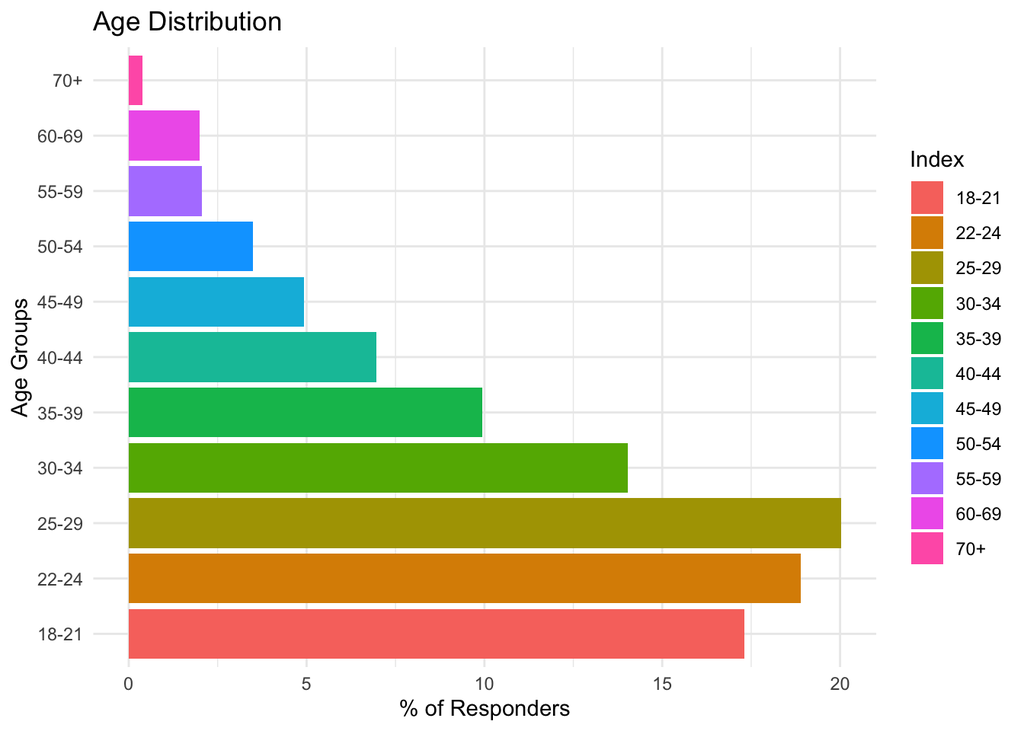

```r
## Q1 - Age

perc_responders <- insights('Q1')

title <- 'Age Distribution'
xlabel <- 'Age Groups'
ylabel <- '% of Responders'

dist_bar_plots(title, xlabel, ylabel)
```

Most People active in the data science space are quite young and lie in 18-34 age bracket.

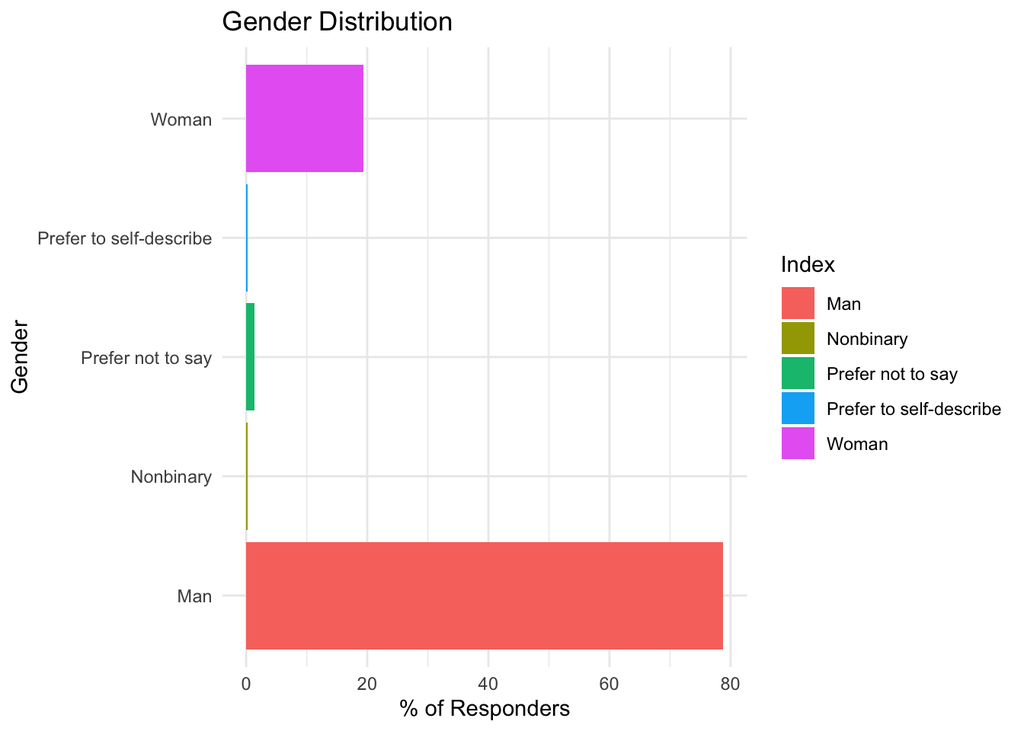

```r
## Q2 - Gender

perc_responders <- insights('Q2')

title <- 'Gender Distribution'
xlabel <- 'Gender'
ylabel <- '% of Responders'

dist_bar_plots(title, xlabel, ylabel)
```

The data science space is largely male dominated with 79% male responders

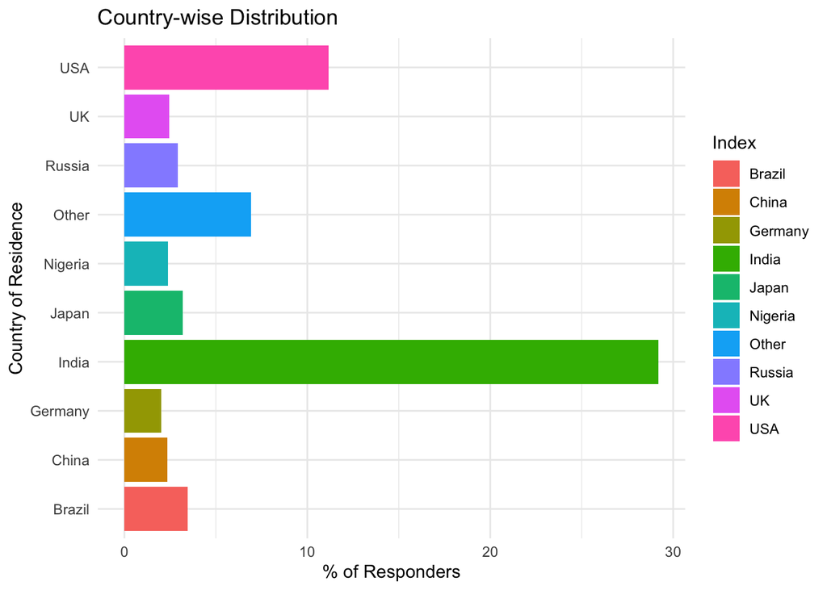

```r
## Q3 - Country Of Residence

perc_responders <- insights('Q3')
perc_responders <- head(perc_responders,10)
perc_responders$Index[perc_responders$Index == 'United Kingdom of Great Britain and Northern Ireland'] <- 'UK'
perc_responders$Index[perc_responders$Index == 'United States of America'] <- 'USA'


title = 'Country-wise Distribution'
xlabel = 'Country of Residence'
ylabel = '% of Responders'

dist_bar_plots(title, xlabel, ylabel)
```

India & The US lead in terms of number of data enthusiasts followed by Brazil, Japan & Russia

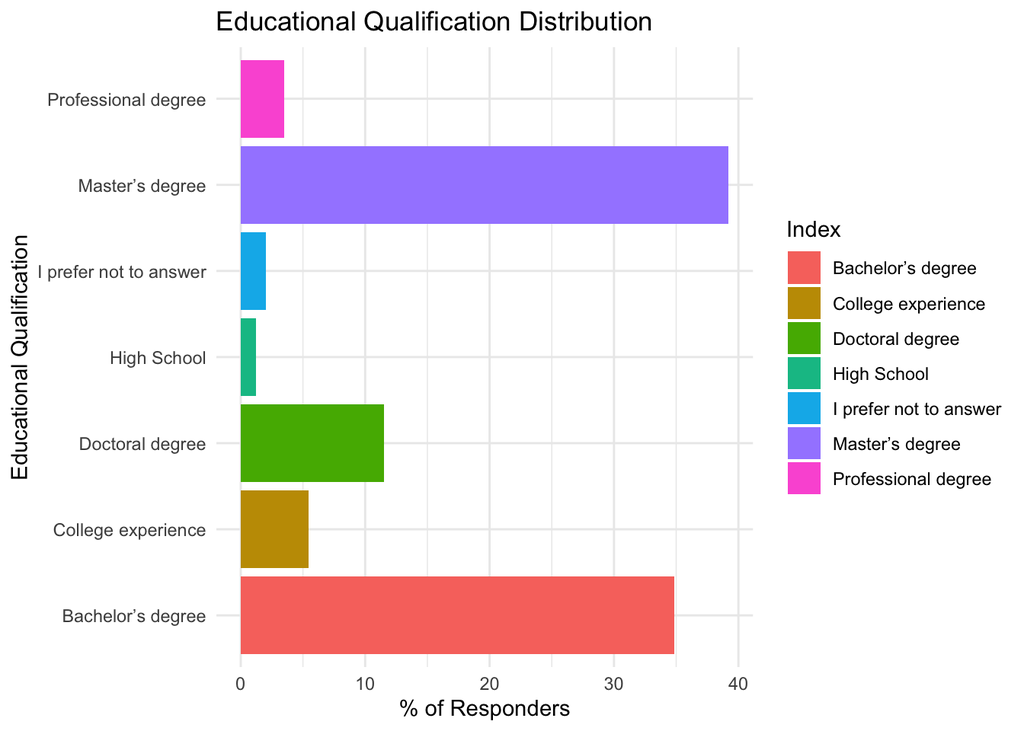

```r
## Q4 - Educational Qualification/Degree

perc_responders <- insights('Q4')
perc_responders$Index[perc_responders$Index == 'Some college/university study without earning a bachelor’s degree'] <- 'College experience'
perc_responders$Index[perc_responders$Index == 'No formal education past high school'] <- 'High School'

title = 'Educational Qualification Distribution'
xlabel = 'Educational Qualification'
ylabel = '% of Responders'

dist_bar_plots(title, xlabel, ylabel)
```

Most data enthusiasts have some college degree (either master’s or bachelor’s followed by doctorates)

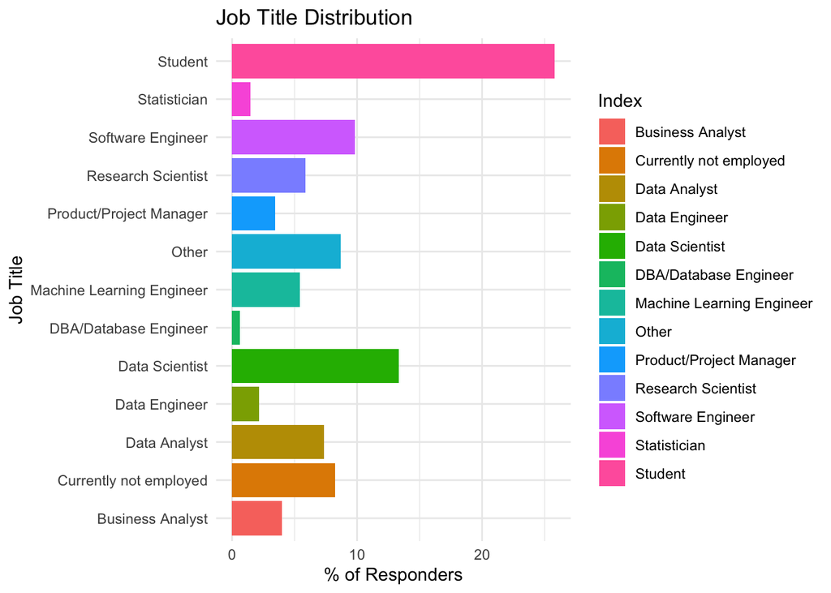

```r
## Q5 - Job Title

perc_responders <- insights('Q5')

title = 'Job Title Distribution'
xlabel = 'Job Title'
ylabel = '% of Responders'

dist_bar_plots(title, xlabel, ylabel)
```

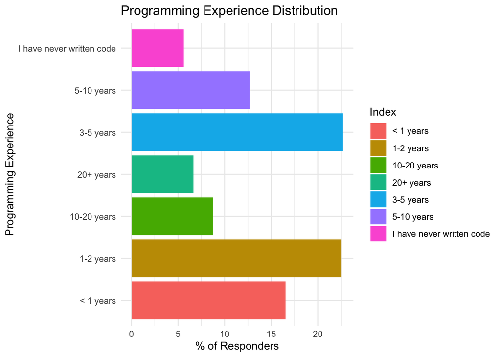

```r
## Q6 - Programming Experience

perc_responders <- insights('Q6')

title = 'Programming Experience Distribution'
xlabel = 'Programming Experience'
ylabel = '% of Responders'

dist_bar_plots(title, xlabel, ylabel)
```

```r
perc_responders
```

```
##                       Index Responder_Percentage
## 1                 3-5 years            22.689160
## 2                 1-2 years            22.484528
## 3                 < 1 years            16.535237
## 4                5-10 years            12.737073
## 5               10-20 years             8.739269
## 6                 20+ years             6.633060
## 7 I have never written code             5.609902
```

60% of the responders lie in 0-5 years bracket. Around 5% of the responders have never written code

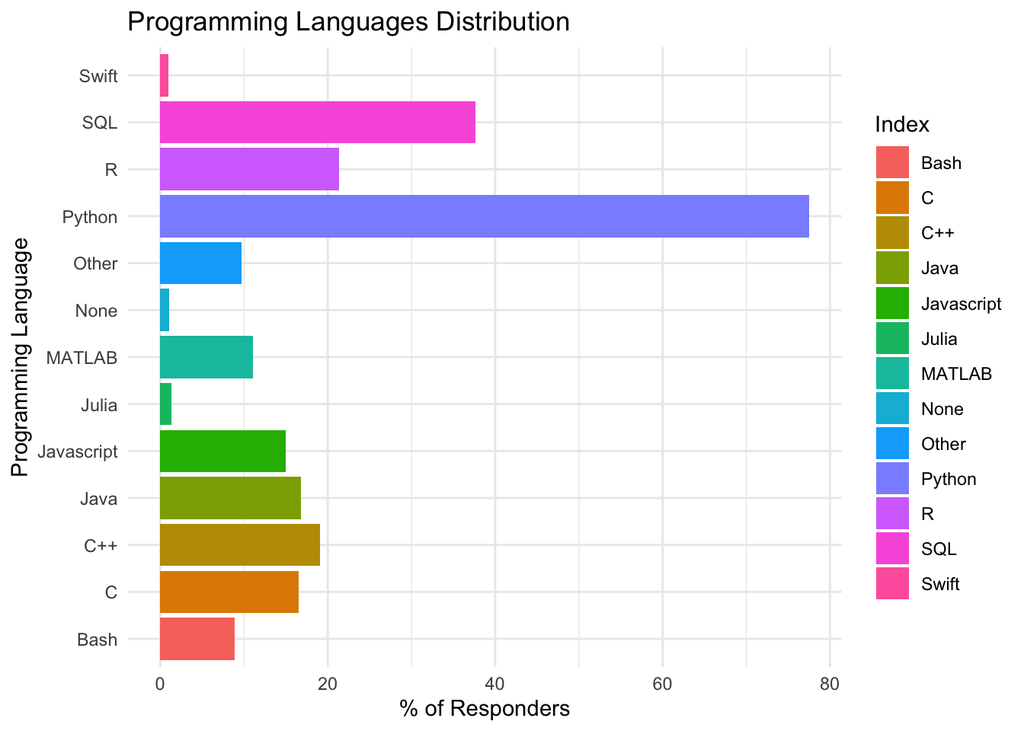

```r
## Q7 - Programming Language

perc_responders = insights('Q7')

title = 'Programming Languages Distribution'
xlabel = 'Programming Language'
ylabel = '% of Responders'

dist_bar_plots(title, xlabel, ylabel)
```

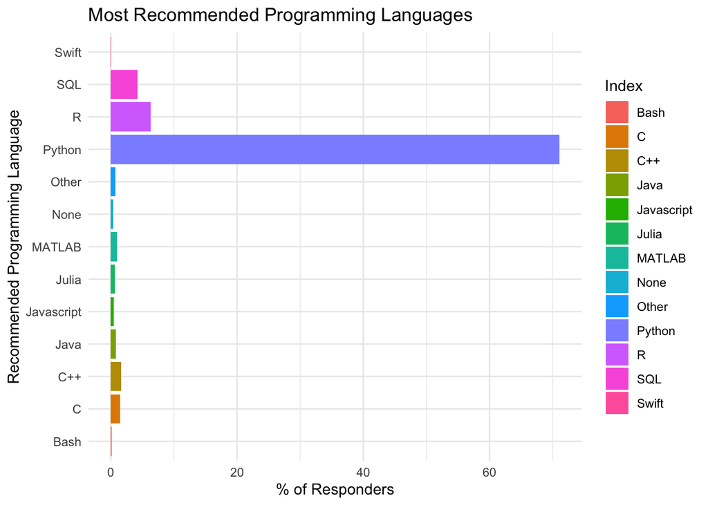

```r
## Q8 - Recommended Programming Language

perc_responders = insights('Q8')

title = 'Most Recommended Programming Languages'
xlabel = 'Recommended Programming Language'
ylabel = '% of Responders'

dist_bar_plots(title, xlabel, ylabel)
```

Python is the most recommended programming language for aspiring data enthusiasts followed by R & SQL

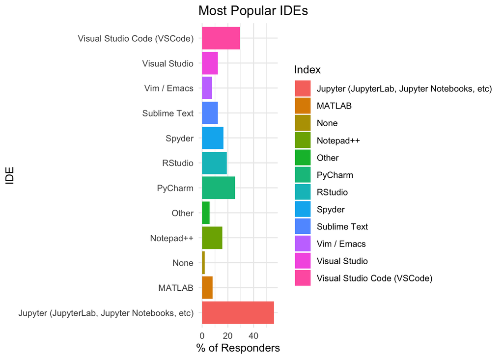

```r
## Q9 - IDE

perc_responders = insights('Q9')

title = 'Most Popular IDEs'
xlabel = 'IDE'
ylabel = '% of Responders'

dist_bar_plots(title, xlabel, ylabel)
```

The popularity of Jupyter Notebooks among data enthusiasts supersedes everything else. VS Code, PyCharm & RStudio are quite popular as well.

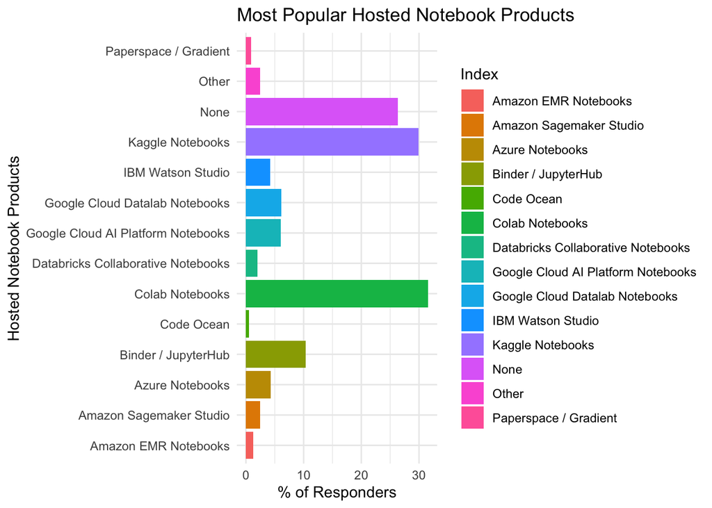

```r
## Q10 - Hosted Notebook Products

perc_responders = insights('Q10')

title = 'Most Popular Hosted Notebook Products'
xlabel = 'Hosted Notebook Products'
ylabel = '% of Responders'

dist_bar_plots(title, xlabel, ylabel)
```

Among hosted notebook products, Google Colab & Kaggle notebooks lead the pack. Google cloud is quite ahead from the competitors Amazon & Microsoft